# Microsimulación Espacial: Tipología de Vivienda en la Región Metropolitana

Diego Ñanculef

2025-06-12

## 1. Introducción

La presente investigación aplica una metodología de Microsimulación espacial utilizando el paquete rakeR, con el objetivo de desagregar a nivel de zona censal la variable “v1” de la Encuesta CASEN 2022, correspondiente al tipo de vivienda que ocupa la persona entrevistada. Esta variable es crítica para el análisis territorial, ya que permite identificar la distribución y concentración de distintas formas de hábitat residencial, las cuales están directamente relacionadas con la calidad de vida, acceso a infraestructura y condiciones socioeconómicas de la población.

Este análisis busca desagregar espacialmente la variable “tipo de vivienda” (v1) de la encuesta CASEN 2022 a nivel de zona censal en el Gran Santiago, mediante la técnica de microsimulación espacial utilizando el paquete rakeR. El objetivo es comprender la distribución territorial de los tipos de vivienda como indicador de condiciones residenciales, y su relación con el contexto socioespacial de la ciudad. El acceso a una vivienda adecuada es uno de los principales determinantes del bienestar de la población urbana. En Chile, el déficit habitacional y la heterogeneidad en la calidad de las viviendas son fenómenos persistentes que reflejan profundas desigualdades territoriales. En este contexto, la presente investigación aplica una metodología de microsimulación espacial utilizando el paquete rakeR con el fin de desagregar la variable “v1” (tipo de vivienda que ocupa la persona entrevistada) de la Encuesta CASEN 2022 a nivel de zona censal en el Gran Santiago. Esta estrategia permite enriquecer la comprensión territorial de las condiciones habitacionales y ofrece herramientas útiles para la planificación urbana y la formulación de políticas públicas.

## 2. Carga de Librerías y Conexión a Base de Datos

En esta sección, se cargan todas las librerías de R necesarias para el análisis (manejo de datos, manipulación espacial, graficación y el paquete de microsimulación rakeR). Además, se establece la conexión a una base de datos PostgreSQL donde se almacenan datos censales y espaciales.

```r
# INSTALAR TODAS LAS LIBRERIAS SOLO 1 VEZ
# =============================================================================
# Estos paquetes permiten conexión a BD, manejo de geometrías y visualización
# install.packages(c("DBI", "RPostgres", "sf", "ggplot2", "data.table", "rakeR", "viridis", "dplyr", "tidyr"))
# =============================================================================
# Cargar librerías necesarias
library(rakeR)
library(RPostgres)
library(DBI)
library(ggplot2)
library(sf)
library(data.table)
library(viridis) # Para las paletas de color viridis en ggplot
library(dplyr)   # Para manipulación de datos
library(tidyr)   # Para la función replace_na
library(here)
# Configurar parámetros de conexión a la base de datos
db_host     = "localhost"
db_port     = 5432
db_name     = "censo_rm_2017"
db_user     = "postgres"
db_password = "postgres"

# Establecer conexión usando RPostgres
con = dbConnect(
  Postgres(),
  dbname    = db_name,
  host      = db_host,
  port      = db_port,
  user      = db_user,
  password = db_password
)
```

## 3. Carga de Datos de Entrada

Para la microsimulación, se utilizan dos fuentes de datos principales:

- cons_censo_df.rds: Contiene las “restricciones” o totales poblacionales agregados por variables demográficas (edad, escolaridad, sexo) a nivel de zonas censales, derivados del Censo 2017. Estos son los totales a los que se ajustarán los datos de la CASEN.
- casen_rm.rds: Contiene los microdatos de la Encuesta CASEN 2022 para la Región Metropolitana. Estos son los datos individuales que se “raquean” (ajustan) a las restricciones censales.

## 4. Marco Teórico

### 4.1 La Microsimulación Espacial y el Análisis Territorial

La microsimulación espacial es una técnica utilizada para generar estimaciones de características individuales en unidades espaciales pequeñas a partir de datos agregados (como los del CENSO) y datos muestrales detallados (como CASEN). En este contexto, el paquete rakeR implementa un algoritmo de ajuste iterativo (raking) que pondera perfiles individuales de acuerdo a restricciones poblacionales conocidas. Esta técnica permite obtener una representación sintética de la población total, que respeta las distribuciones del CENSO 2017 pero incorpora variables no observadas directamente en dicho instrumento, como es el caso del tipo de vivienda.

La variable “v1” de CASEN fue recodificada para clasificar las viviendas en cuatro categorías: (1) vivienda formal de alta calidad; (2) vivienda formal de menor calidad; (3) vivienda precaria o informal; y (4) vivienda tradicional o cultural específica. Esta clasificación permite realizar un análisis más robusto y territorialmente significativo sobre la calidad del hábitat residencial en el Gran Santiago.

### 4.2 La Vivienda como Dimensión Estructural de la Desigualdad Urbana

La vivienda no solo cumple funciones básicas de abrigo y privacidad, sino que representa un nodo donde convergen múltiples determinantes sociales: seguridad, acceso a servicios básicos, conectividad y capital social. En las áreas metropolitanas, las formas de acceso a la vivienda se encuentran fuertemente estratificadas y responden a patrones de segmentación socioeconómica y segregación espacial. Diversas investigaciones han documentado que las viviendas precarias y los asentamientos informales tienden a concentrarse en las periferias urbanas, reforzando ciclos de exclusión social y económica.

La relación con el ingreso es un factor clave:

- Personas que viven en departamentos con ascensor o casas aisladas tienden a tener mayores ingresos.
- Personas que viven en mediaguas, viviendas precarias o piezas en conventillos suelen tener ingresos significativamente más bajos.

Aunque la mayoría vive en casas (aisladas o pareadas), existe una diversidad que permite hacer comparaciones relevantes, especialmente al agrupar los tipos de vivienda en categorías. Esto permite hacer análisis más sólidos con menos ruido estadístico y comparar, por ejemplo:

- Porcentaje de personas en viviendas precarias por comuna vs. ingreso promedio per cápita.
- Comparar el ingreso promedio de personas según el tipo de vivienda.

Es importante considerar las limitaciones: algunos tipos de vivienda tienen una frecuencia muy baja (como viviendas indígenas, ranchos o viviendas precarias). Estas categorías podrían ser poco útiles en un análisis comunal si hay muchas comunas sin casos. Por ello, se sugiere agrupar los 10 tipos de vivienda en 4 categorías socioeconómicas más amplias para lograr un análisis más robusto y útil.

## 5. Prepraración y Transformación de CASEN

Esta sección se encarga de preparar los datos para la microsimulación y el análisis posterior. Se identifican las columnas relevantes, se limpian y transforman las variables, y se recodifican en categorías que coincidan entre los datos de la CASEN y los datos censales de restricción.

## 6. Recodificación y Modelamiento de Variables

Aquí se realizan transformaciones adicionales a las variables para que sean adecuadas para la microsimulación y el análisis de vivienda precaria. Esto incluye la recodificación de la variable “v1” en categorías de vivienda y la imputación de datos faltantes en la escolaridad.

## 7. Metodología

Se trabajó con datos del CENSO 2017 ya procesados a nivel de zona censal para la Región Metropolitana y con la base de datos CASEN 2022 filtrada para las comunas del Gran Santiago. Se seleccionaron variables sociodemográficas comunes a ambos instrumentos para la construcción de perfiles: edad, sexo y escolaridad.

Se procedió con la imputación de datos faltantes (escolaridad) utilizando regresión lineal sobre el ingreso autónomo (e6a) y la creación de variables categóricas para las restricciones. Posteriormente, se ejecutó el procedimiento de microsimulación para cada comuna, generando pesos fraccionales y una versión entera de la población sintética. La variable “v1” fue incluida en la población simulada, lo que permitió calcular su distribución relativa por zona censal. Finalmente, estos resultados fueron integrados a una capa geográfica para su visualización espacial mediante mapas temáticos.

Se utilizó el paquete rakeR en R para aplicar un procedimiento de microsimulación espacial que incluyó las siguientes etapas:

- Preprocesamiento de datos CASEN 2022 para la Región Metropolitana, incluyendo imputación de valores faltantes en escolaridad (esc) y categorización de edad, sexo y escolaridad.
- Integración con restricciones estructurales derivadas del CENSO 2017 a nivel de zona censal.
- Simulación de la población completa por comuna mediante el ajuste de pesos con raking y posterior integerise.
- Cálculo del porcentaje de personas que habitan cada tipo de vivienda en cada zona censal del Gran Santiago.
- Visualización mediante mapas temáticos generados con ggplot2 y sf.

  ```r
  inds_list <- split(casen, casen$Comuna)
  cons_censo_list <- split(cons_censo_df, cons_censo_df$COMUNA)

  # Diagnóstico útil para evitar errores por comunas sin correspondencia
  cat("Comunas solo en CASEN:\n")
  ```

  ```
  ## Comunas solo en CASEN:
  ```

  ```r
  print(setdiff(names(inds_list), names(cons_censo_list)))
  ```

  ```
  ##  [1] "13202" "13203" "13301" "13302" "13303" "13402" "13403" "13404" "13501"
  ## [10] "13502" "13503" "13504" "13505" "13601" "13602" "13603" "13604" "13605"
  ```

  ```r
  cat("Comunas solo en CENSO:\n")
  ```

  ```
  ## Comunas solo en CENSO:
  ```

  ```r
  print(setdiff(names(cons_censo_list), names(inds_list)))
  ```

  ```
  ## character(0)
  ```

  ```r
  # MICROSIMULACIÓN ESPACIAL
  sim_list <- lapply(names(cons_censo_list), function(comuna) {
    cons_i <- cons_censo_list[[comuna]]
    inds_i <- inds_list[[comuna]]
    if (is.null(inds_i)) return(NULL)

    cons_i <- cons_i[, c("GEOCODIGO", sort(setdiff(names(cons_i), c("COMUNA", "GEOCODIGO"))))]
    inds_sub <- inds_i[, c("ID", "edad_cat", "esc_cat", "sexo_cat")]
    colnames(inds_sub) <- c("ID", "Edad", "Escolaridad", "Sexo")

    w <- weight(cons_i, inds_sub, vars = c("Edad", "Escolaridad", "Sexo"))
    sim_i <- integerise(w, inds_sub, seed = 123)
    sim_i$GEOCODIGO <- cons_i$GEOCODIGO[1]

    merge(sim_i, inds_i[, c("ID", "v1")], by = "ID", all.x = TRUE)
  })

  sim_df <- rbindlist(sim_list, idcol = "COMUNA", fill = TRUE)
  ```

## 8. Tablas resumen y análisis exploratorio

### 8.2 Relación con Otras Variables y Utilidad para Políticas Públicas

  La utilidad de contar con esta información espacialmente desagregada es inmensa para la formulación de políticas públicas y la planificación territorial:
  - Focalización de Políticas: Permite identificar con precisión zonas críticas que requieren intervenciones focalizadas en políticas de vivienda, subsidios, mejoramiento barrial, o acceso a servicios. En lugar de aplicar soluciones generales, se pueden diseñar programas específicos para las áreas de mayor necesidad.
  - Asignación de Recursos: Facilita una asignación más eficiente y equitativa de recursos públicos y privados, dirigiendo las inversiones donde realmente se necesita un impacto en la calidad habitacional.
  - Monitoreo y Evaluación: Provee una línea base espacial para monitorear los efectos de las políticas a lo largo del tiempo y evaluar si están logrando reducir la precariedad en las zonas objetivo.
  - Planificación Urbana Integrada: Ofrece herramientas valiosas para la planificación del crecimiento urbano, la infraestructura y los servicios, considerando las necesidades habitacionales y socioeconómicas de cada sector.

  El aporte de esta metodología radica en su capacidad de generar información territorial de alta resolución a partir de datos secundarios, sin necesidad de levantamientos adicionales de campo costosos y complejos.

  ```
  ## # A tibble: 34 × 2
  ##    COMUNA casos_simulados
  ##     <int>           <int>
  ##  1     33          568106
  ##  2     19          521627
  ##  3      1          404495
  ##  4     10          366916
  ##  5     34          301313
  ##  6     14          294838
  ##  7     22          241599
  ##  8     24          230293
  ##  9     25          210410
  ## 10     20          208237
  ## # ℹ 24 more rows
  ```

  ```
  ## # A tibble: 92 × 4
  ## # Groups:   COMUNA [34]
  ##    COMUNA tipo_vivienda  total porcentaje
  ##     <int>         <dbl>  <int>      <dbl>
  ##  1      1             1 338850      83.8
  ##  2      1             2  54074      13.4
  ##  3      1             3  11571       2.86
  ##  4      2             1  64551      79.9
  ##  5      2             2  16281      20.1
  ##  6      3             1 123297      93.0
  ##  7      3             2   9325       7.03
  ##  8      4             1 109039      85.9
  ##  9      4             2  17916      14.1
  ## 10      5             1 133820      82.4
  ## # ℹ 82 more rows
  ```

  ```
  ## # A tibble: 34 × 2
  ##    COMUNA porc_precarias
  ##     <int>          <dbl>
  ##  1      6           4.46
  ##  2     17           3.21
  ##  3     27           3.18
  ##  4      1           2.86
  ##  5     18           1.89
  ##  6     24           1.8
  ##  7     26           1.69
  ##  8     16           1.35
  ##  9      7           1.11
  ## 10      8           0.94
  ## # ℹ 24 more rows
  ```

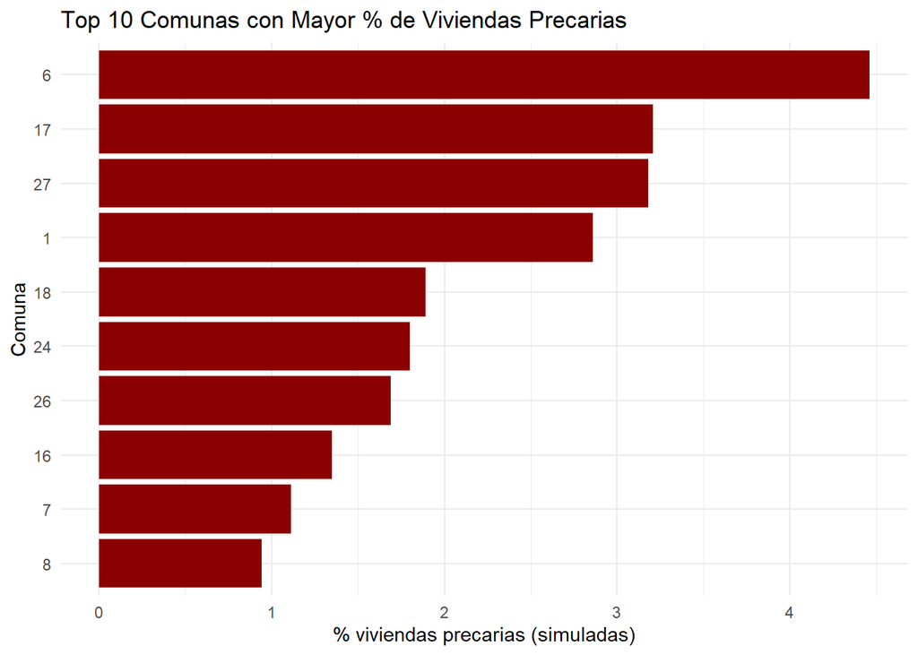

## 9. Cálculo de porcentaje de Viviendas Precarias por GEOCODIGO

  ```r
  zonas_v1 <- sim_df %>%
    filter(!is.na(v1)) %>%
    group_by(GEOCODIGO) %>%
    summarise(vivienda_precaria = round(100 * sum(v1 == 3) / n(), 2)) %>%
    ungroup()
  ```

## 10. Exportar base de datos y unión espacial

  ```r
  dbExecute(con, "DROP TABLE IF EXISTS dpa.tmp_v1_rm")
  ```

  ```
  ## [1] 0
  ```

  ```r
  dbWriteTable(con, Id(schema = "dpa", table = "tmp_v1_rm"), zonas_v1, overwrite = TRUE)

  # Aquí corregimos el nombre de columna a GEOCODIGO (en mayúsculas)
  dbExecute(con, "CREATE INDEX ON dpa.tmp_v1_rm(\"GEOCODIGO\")")
  ```

  ```
  ## [1] 0
  ```

  ```r
  dbExecute(con, "ANALYZE dpa.tmp_v1_rm")
  ```

  ```
  ## [1] 0
  ```

  ```r
  # Usamos comillas para asegurar referencia correcta
  dbExecute(con, "DROP TABLE IF EXISTS dpa.zonas_v1")
  ```

  ```
  ## [1] 0
  ```

  ```r
  dbExecute(con, "
    CREATE TABLE dpa.zonas_v1 AS
    SELECT z.*, t.vivienda_precaria
    FROM dpa.zonas_censales_rm z
    LEFT JOIN dpa.tmp_v1_rm t ON z.geocodigo::text = t.\"GEOCODIGO\"
    WHERE urbano = 1 AND (
      nom_provin = 'SANTIAGO' OR
      nom_comuna IN ('PEDRO AGUIRRE CERDA', 'LO ESPEJO')
    )
  ")
  ```

  ```
  ## [1] 2868
  ```

## 11. Visualización final en mapa

  La visualización mediante mapas temáticos a nivel de zona censal permitió identificar patrones espaciales de manera clara. Para mejorar la legibilidad, se aplicó una escala de color degradada y se excluyeron zonas no urbanas del análisis. Este tipo de representación facilita la interpretación para actores técnicos y autoridades territoriales.

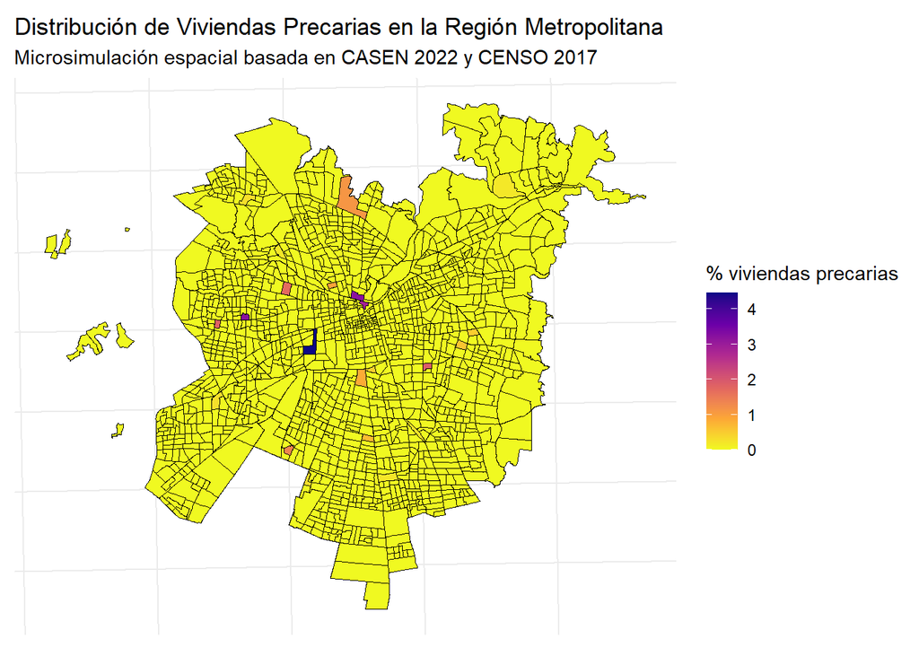

  ```r
  zonas_v1_sf <- st_read(con, query = "SELECT * FROM dpa.zonas_v1")

  zonas_v1_sf <- zonas_v1_sf %>%
    mutate(vivienda_precaria = replace_na(vivienda_precaria, 0))

  ggplot(zonas_v1_sf) +
    geom_sf(aes(fill = vivienda_precaria), color = "black", size = 0.2) +
    scale_fill_viridis_c(option = "C", direction = -1,
                         name = "% viviendas precarias") +
    theme_minimal() +
    labs(
      title = "Distribución de Viviendas Precarias en la Región Metropolitana",
      subtitle = "Microsimulación espacial basada en CASEN 2022 y CENSO 2017"
    ) +
    theme(axis.text = element_blank(), axis.ticks = element_blank())
  ```

## 12. Conclusión

  La microsimulación espacial de la variable “v1” permite desagregar de forma robusta y técnicamente fundamentada un aspecto clave del bienestar residencial a una escala territorial fina. Este análisis evidencia la existencia de patrones de desigualdad estructural en el acceso a vivienda adecuada dentro del Gran Santiago y proporciona una herramienta útil para el diseño de políticas públicas de vivienda y planificación urbana.

  El uso de esta metodología permite complementar los datos censales con información valiosa de encuestas sociales, aumentando la capacidad diagnóstica a nivel local sin requerir nuevas encuestas exhaustivas. Esta aproximación debe consolidarse como herramienta estándar en análisis espaciales aplicados a temas sociales y urbanos.

  El presente estudio demuestra el potencial de la microsimulación espacial para desagregar variables relevantes del bienestar urbano, como el tipo de vivienda, a niveles territoriales finos. La variable “v1” de la CASEN 2022, procesada mediante el paquete rakeR y combinada con datos del CENSO 2017, permitió construir una base sólida para el análisis espacial de las condiciones habitacionales en el Gran Santiago.

  Los resultados evidencian la persistencia de desigualdades territoriales en materia de vivienda, lo que refuerza la necesidad de políticas públicas más focalizadas y territoriales. Además, se valida el uso de herramientas de ciencia de datos aplicadas a la planificación urbana, abriendo nuevas posibilidades para el diseño de ciudades más justas y equitativas.